# Statistical Inference Course Project (Part 2)

Annette Spithoven

3-11-2019

## 1. Overview

The purpose of the this data analysis is to analyze the ToothGrowth data set. This dataset contains information guinea tooth growth by supplement and dose. We will perform exploratory analysis and hypothesis testing to figure out is there a relationship between tooth growth and daily dosage of vitamin C through various supplements.

```r
## loading the data
data("ToothGrowth")

## make it an environment object
ToothGrowth <- ToothGrowth
```

## 2. Basic Summary of the Data

The basic summary of the data start with an examination of the data structure.

```r
str(ToothGrowth)
```

```
## 'data.frame':    60 obs. of  3 variables:
##  $ len : num  4.2 11.5 7.3 5.8 6.4 10 11.2 11.2 5.2 7 ...
##  $ supp: Factor w/ 2 levels "OJ","VC": 2 2 2 2 2 2 2 2 2 2 ...
##  $ dose: num  0.5 0.5 0.5 0.5 0.5 0.5 0.5 0.5 0.5 0.5 ...
```

The supp variable exist of two levels, OJ and VC. We rename those so that they are clearer. In addition, we will take a look at the information in the dataframe.

```r
## rename the levels
levels(ToothGrowth$supp) <- c("Orange Juice", "Ascorbic Acid")

## provide summary
summary(ToothGrowth)
```

```
##       len                   supp         dose
##  Min.   : 4.20   Orange Juice :30   Min.   :0.500
##  1st Qu.:13.07   Ascorbic Acid:30   1st Qu.:0.500
##  Median :19.25                      Median :1.000
##  Mean   :18.81                      Mean   :1.167
##  3rd Qu.:25.27                      3rd Qu.:2.000
##  Max.   :33.90                      Max.   :2.000
```

We conduct a simple check to see whether the outcome (tooth length) is approximately normally distributed (assumption of t-test).

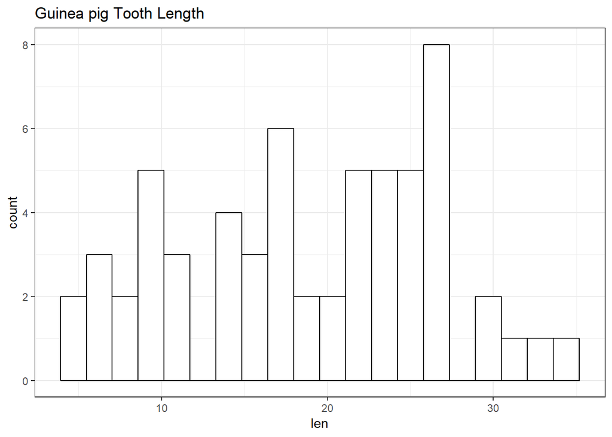

```r
ggplot(ToothGrowth,
       aes(len)) +
  geom_histogram(bins=20,
                 fill = "white",
                 col = "black")+
  ## change titles
  labs(title="Guinea pig Tooth Length")+
  theme_bw()
```

In addition, we plot some of the information.

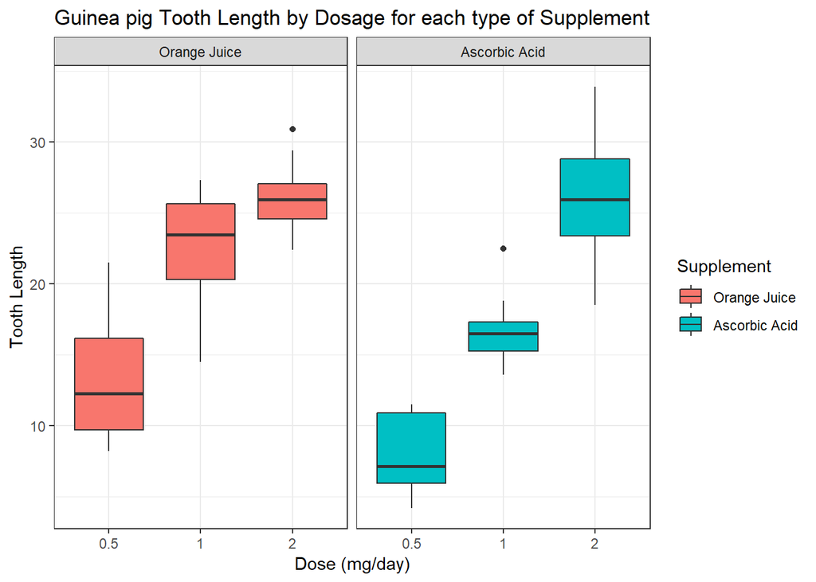

```r
ggplot(ToothGrowth,
       aes(x=as.character(dose),
           y=len,
           fill = supp)) +
  ## make boxplots
  geom_boxplot() +
    ## seperate by supplement
  facet_grid(.~supp) +
  ## change titles
  labs(title="Guinea pig Tooth Length by Dosage for each type of Supplement",
    x="Dose (mg/day)",
    y="Tooth Length",
    fill = "Supplement")+
  theme_bw()
```

## Use confidence intervals & hypothesis tests to compare tooth growth by supplement and dose

There are several questions that can be answered with the current data. One question is whether the supplement has an effect on tooth growth. Another question is whether the dose has an effect on tooth growth. The last question concerns whether the combination of dose and supplement has and effect on tooth growht.

### H0: The supplement does not have any influence on the tooth growth

The first hypothesis tested is whether the supplement has an effect on tooth growth. The alternative hypothesis (H1) is that there is an effect of supplement on tooth growth.

```r
t.test(len ~ supp, data = ToothGrowth, paired=FALSE)
```

```
##
##  Welch Two Sample t-test
##
## data:  len by supp
## t = 1.9153, df = 55.309, p-value = 0.06063
## alternative hypothesis: true difference in means is not equal to 0
## 95 percent confidence interval:
##  -0.1710156  7.5710156
## sample estimates:
##  mean in group Orange Juice mean in group Ascorbic Acid
##                    20.66333                    16.96333
```

The analysis indicates that we cannot reject the null hypothesis. In other words there is no effect of supplement on tooth growth.

### H0: The dose has no effect on tooth growth

For the second question we will examine whether dose has an effect on tooth growth. We make three different datasets to test these hypotheses.

```r
ToothGrowth0.5_1 <- ToothGrowth %>%
  filter(dose != 2)

ToothGrowth1_2 <- ToothGrowth %>%
  filter(dose != 0.5)

ToothGrowth0.5_2 <- ToothGrowth %>%
  filter(dose != 1)
```

First, we compare the dosage 0.5 and 1.

```r
t.test(len ~ dose, data = ToothGrowth0.5_1, paired=FALSE)
```

```
##
##  Welch Two Sample t-test
##
## data:  len by dose
## t = -6.4766, df = 37.986, p-value = 1.268e-07
## alternative hypothesis: true difference in means is not equal to 0
## 95 percent confidence interval:
##  -11.983781  -6.276219
## sample estimates:
## mean in group 0.5   mean in group 1
##            10.605            19.735
```

Second, we compare the dosage 1 and 2.

```r
t.test(len ~ dose, data = ToothGrowth1_2, paired=FALSE)
```

```
##
##  Welch Two Sample t-test
##
## data:  len by dose
## t = -4.9005, df = 37.101, p-value = 1.906e-05
## alternative hypothesis: true difference in means is not equal to 0
## 95 percent confidence interval:
##  -8.996481 -3.733519
## sample estimates:
## mean in group 1 mean in group 2
##          19.735          26.100
```

Third, we compare the dosage 0.5 and 2.

```r
t.test(len ~ dose, data = ToothGrowth0.5_2, paired=FALSE)
```

```
##
##  Welch Two Sample t-test
##
## data:  len by dose
## t = -11.799, df = 36.883, p-value = 4.398e-14
## alternative hypothesis: true difference in means is not equal to 0
## 95 percent confidence interval:
##  -18.15617 -12.83383
## sample estimates:
## mean in group 0.5   mean in group 2
##            10.605            26.100
```

All t-tests for the dosage are significant, so we can reject the null hypotheses. This suggest that the dosage does influence the tooth growth. Examining the means, it appears that the greater the dosage the greater the tooth length.

### H0: The combination of dosage and supplement doesn’t influence tooth growth.

First, we compare the dosage 0.5

```r
ToothGrowth0.5 <- ToothGrowth %>%
  filter(dose == 0.5)

t.test(len ~ supp, data = ToothGrowth0.5, paired=FALSE)
```

```
##
##  Welch Two Sample t-test
##
## data:  len by supp
## t = 3.1697, df = 14.969, p-value = 0.006359
## alternative hypothesis: true difference in means is not equal to 0
## 95 percent confidence interval:
##  1.719057 8.780943
## sample estimates:
##  mean in group Orange Juice mean in group Ascorbic Acid
##                       13.23                        7.98
```

Second, we compare the dosage 1.

```r
ToothGrowth1 <- ToothGrowth %>%
  filter(dose == 1)

t.test(len ~ supp, data = ToothGrowth1, paired=FALSE)
```

```
##
##  Welch Two Sample t-test
##
## data:  len by supp
## t = 4.0328, df = 15.358, p-value = 0.001038
## alternative hypothesis: true difference in means is not equal to 0
## 95 percent confidence interval:
##  2.802148 9.057852
## sample estimates:
##  mean in group Orange Juice mean in group Ascorbic Acid
##                       22.70                       16.77
```

Third, we compare the dosage 2.

```r
ToothGrowth2 <- ToothGrowth %>%
  filter(dose == 2)

t.test(len ~ supp, data = ToothGrowth2, paired=FALSE)
```

```
##
##  Welch Two Sample t-test
##
## data:  len by supp
## t = -0.046136, df = 14.04, p-value = 0.9639
## alternative hypothesis: true difference in means is not equal to 0
## 95 percent confidence interval:
##  -3.79807  3.63807
## sample estimates:
##  mean in group Orange Juice mean in group Ascorbic Acid
##                       26.06                       26.14
```

The t-tests for the dosages 0.5 and 1 are significant, indicating that the null hypothesis could be rejected. For the dosage of 0.5 and 1, Orange Juice resulted in longer tooth than Ascorbic Acid. The t-test for the dosage 2 is greater than 0.05 and thus not significant. This suggest the null hypothesis cannot be reject, with a dosage of 2 it doesn’t matter whether you use orange juice or ascorbic acid.